# Assigment_02

Hasan Palaz

October 21, 2017

###### Q1

Create two matrices from the given set of numbers X1 = {2,3,7,1,6,2,3,5,1} and x2 = {3,2,9,0,7,8,5,8,2}

###### A1

```r
# Define X1 and X2 datasets
X1 <- c(2,3,7,1,6,2,3,5,1)
X2 <- c(3,2,9,0,7,8,5,8,2)

# Create 3x3 matrix_01 and matrix_02 from X1 and X2 vectors
matrix_01 <- matrix(X1, ncol=3)
matrix_02 <- matrix(X2, ncol=3)

# Lets's look our new matrices
matrix_01
```

```
##      [,1] [,2] [,3]
## [1,]    2    1    3
## [2,]    3    6    5
## [3,]    7    2    1
```

```r
matrix_02
```

```
##      [,1] [,2] [,3]
## [1,]    3    0    5
## [2,]    2    7    8
## [3,]    9    8    2
```

###### Q2

Find the matrix product.

###### A2

```r
# multiplication of matrix_01 and matrix_02
matrix_03 <- matrix_01 %*% matrix_02
matrix_03
```

```
##      [,1] [,2] [,3]
## [1,]   35   31   24
## [2,]   66   82   73
## [3,]   34   22   53
```

###### Q3

What does correlation coefficient represent? How do you find the correlation between (i) two categorical variables and (ii) categorical variable and continuous variable.

###### A3

What does correlation coefficient represent?

1. In statistics, the correlation coefficient r measures the strength and direction of a linear relationship between two variables on a scatterplot. The value of r is always between +1 and –1.
2. The further an r value is from zero, the stronger the relationship between the two variables.
3. The sign of r indicates the nature of relationship. A positive r indicates a positive relationship, and a negative r indicates a negative relationship.

How do you find the correlation between two categorical variables?

1. Contingency Tables, two way table and stacked column plot are used to find the correlation between two categorical variables.

How do you find the correlation between categorical variable and continuous variable?

1. Z-test/t-test and ANOVA are used to find the correlation between categorical variable and continuous variable.

###### Q4

Load the Animals data set from the “MASS” package

###### A4

```r
# If the MASS package is not installed, firstly we do that:
#install.packages('MASS')
library(MASS)
data(Animals)
head(Animals)
```

```
##                     body brain
## Mountain beaver     1.35   8.1
## Cow               465.00 423.0
## Grey wolf          36.33 119.5
## Goat               27.66 115.0
## Guinea pig          1.04   5.5
## Dipliodocus     11700.00  50.0
```

###### Q5

Find the correlation coefficient of brain and body in this data set and comment on the relation between them

###### A5

```r
# Correlation coefficient of brain and body in Animals dataset
cor(Animals$body, Animals$brain)
```

```
## [1] -0.005341163
```

Comment on the relation betweenbrain and body:

1. There is no relation (correlation) between brain and body in Animals dataset. Because, the correlation of brain and body in Animals dataset is -0.00534, around ZERO.

###### Q6

Load USArrests data set. Comment on the distribution of the variables. Is there any relation between UrbanPop and three crimes?

###### A6

Load USArrests data set.

```r
# Load USArrest data set and check details
data(USArrests)
USArrests
```

[output not shown]

```r
names(USArrests)
```

```
## [1] "Murder"   "Assault"  "UrbanPop" "Rape"
```

```r
head(USArrests)
```

```
##            Murder Assault UrbanPop Rape
## Alabama      13.2     236       58 21.2
## Alaska       10.0     263       48 44.5
## Arizona       8.1     294       80 31.0
## Arkansas      8.8     190       50 19.5
## California    9.0     276       91 40.6
## Colorado      7.9     204       78 38.7
```

```r
dim(USArrests)
```

```
## [1] 50  4
```

Comment on the distribution of the variables.

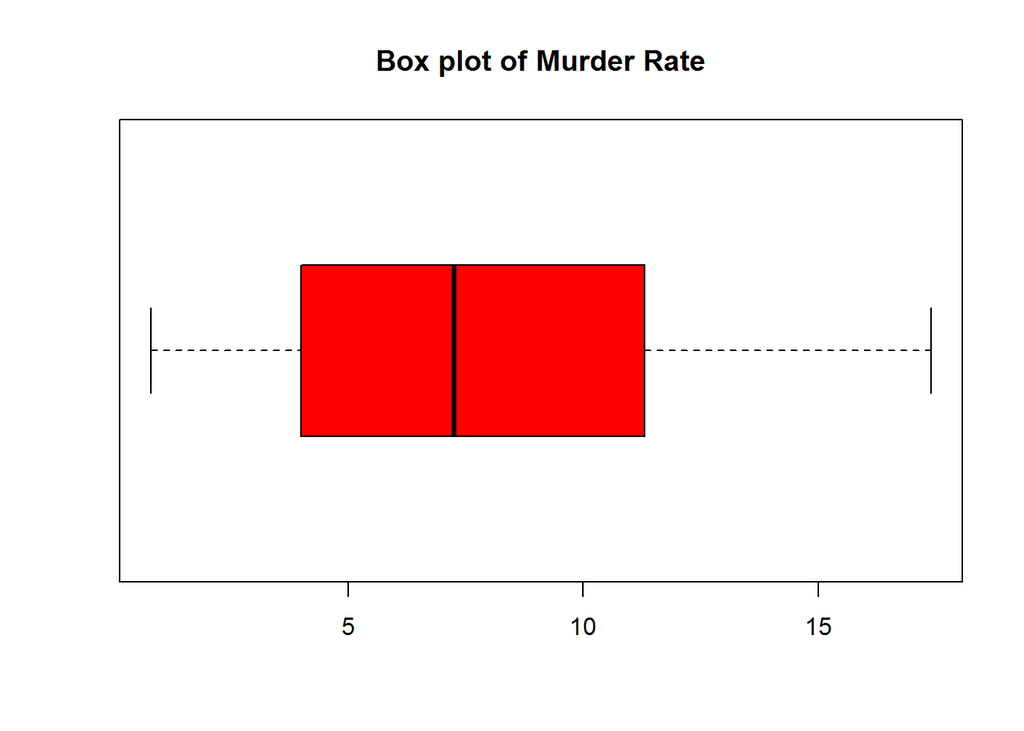

```r
boxplot(USArrests$Murder, horizontal=TRUE, col= c("red"),main="Box plot of Murder Rate")
```

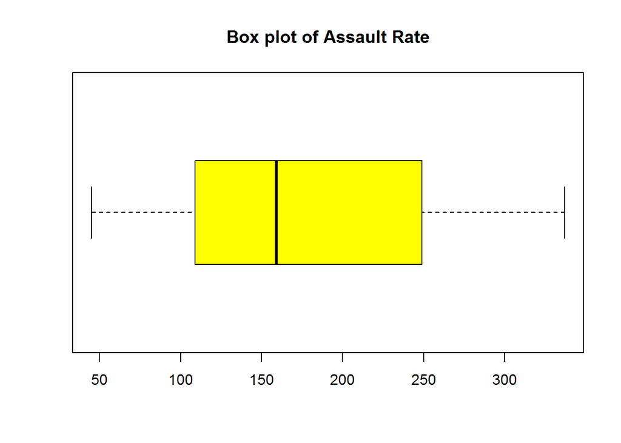

```r
boxplot(USArrests$Assault, horizontal=TRUE, col= c("yellow"),main="Box plot of Assault Rate")
```

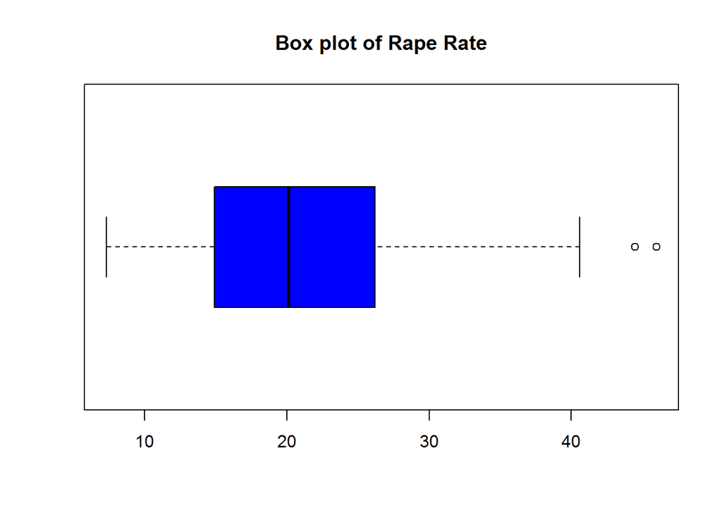

```r
boxplot(USArrests$Rape, horizontal=TRUE, col= c("blue"),main="Box plot of Rape Rate")
```

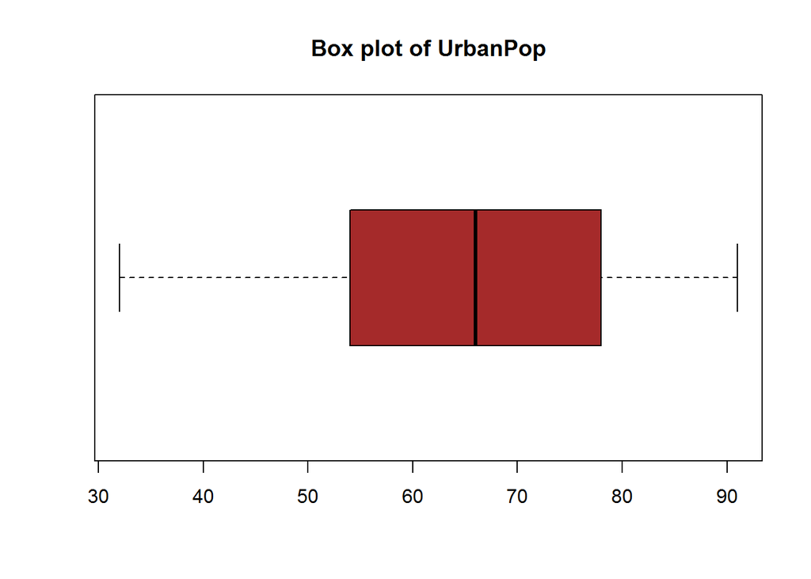

```r
boxplot(USArrests$UrbanPop, horizontal=TRUE, col= c("brown"),main="Box plot of UrbanPop")
```

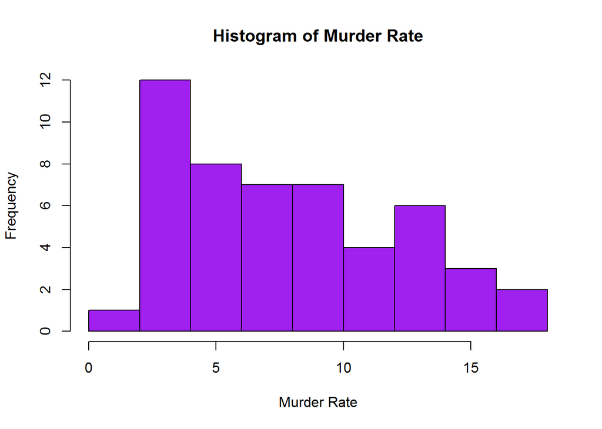

```r
hist(USArrests$Murder, col="purple",main="Histogram of Murder Rate",xlab="Murder Rate")
```

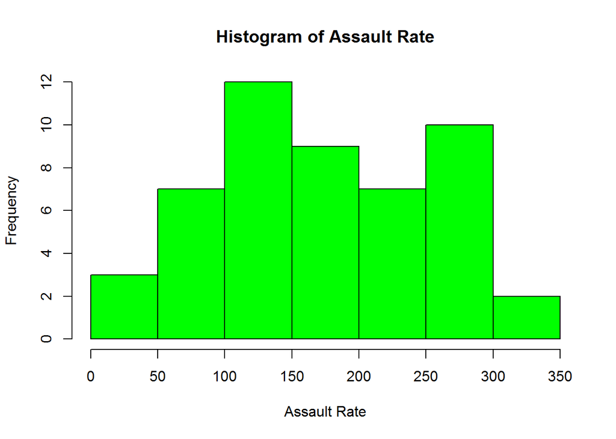

```r
hist(USArrests$Assault, col="green",main="Histogram of Assault Rate",xlab="Assault Rate")
```

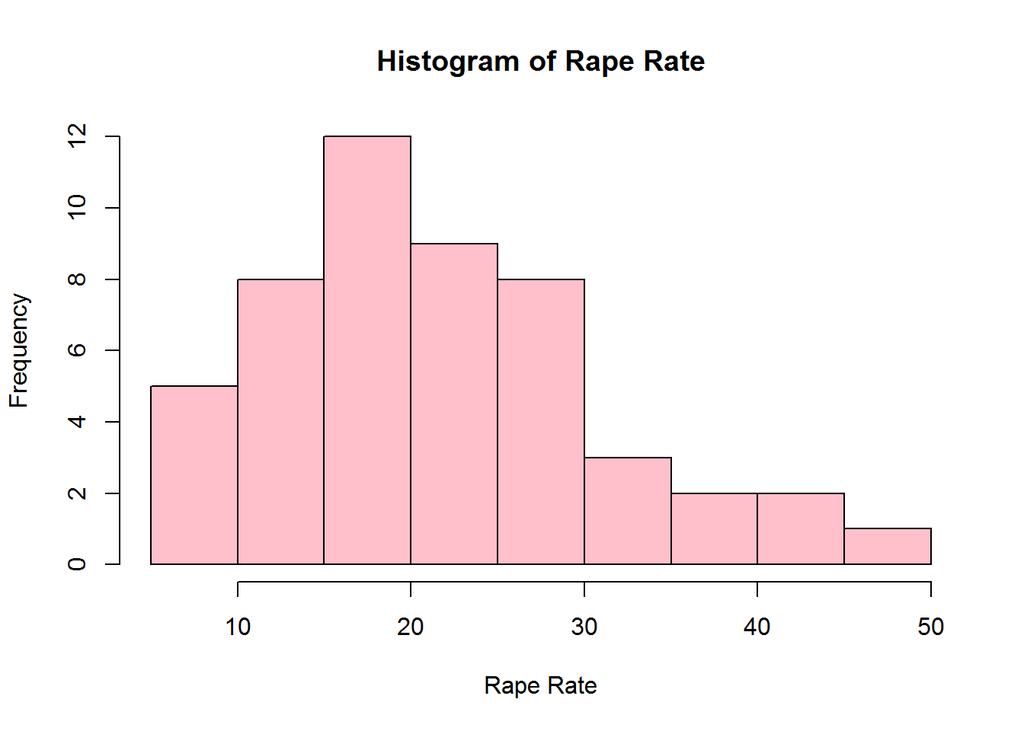

```r
hist(USArrests$Rape, col="pink",main="Histogram of Rape Rate",xlab="Rape Rate")
```

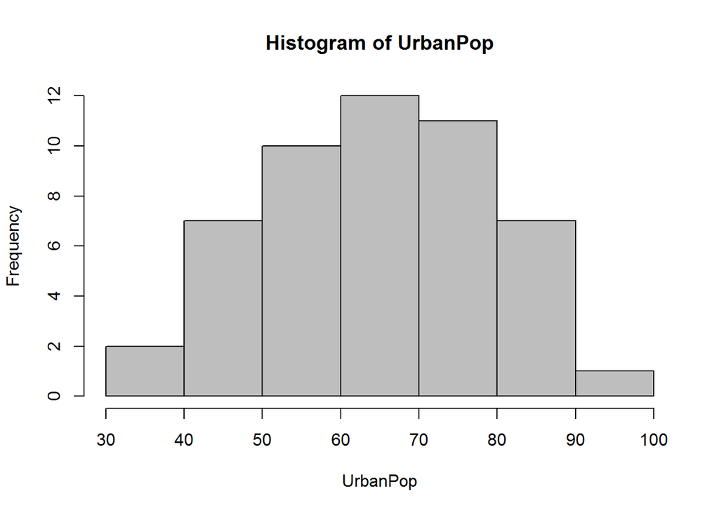

```r
hist(USArrests$UrbanPop, col="gray",main="Histogram of UrbanPop",xlab="UrbanPop")
```

```r
summary(USArrests)
```

```
##      Murder          Assault         UrbanPop          Rape
##  Min.   : 0.800   Min.   : 45.0   Min.   :32.00   Min.   : 7.30
##  1st Qu.: 4.075   1st Qu.:109.0   1st Qu.:54.50   1st Qu.:15.07
##  Median : 7.250   Median :159.0   Median :66.00   Median :20.10
##  Mean   : 7.788   Mean   :170.8   Mean   :65.54   Mean   :21.23
##  3rd Qu.:11.250   3rd Qu.:249.0   3rd Qu.:77.75   3rd Qu.:26.18
##  Max.   :17.400   Max.   :337.0   Max.   :91.00   Max.   :46.00
```

Is there any relation between UrbanPop and three crimes? Firstly, correlation coefficients of the USArrest are calculated

```r
# Correlation coefficient of the USArrests dataset
cor(USArrests)
```

```
##              Murder   Assault   UrbanPop      Rape
## Murder   1.00000000 0.8018733 0.06957262 0.5635788
## Assault  0.80187331 1.0000000 0.25887170 0.6652412
## UrbanPop 0.06957262 0.2588717 1.00000000 0.4113412
## Rape     0.56357883 0.6652412 0.41134124 1.0000000
```

Secondly, Scatter Plots of the USArrest should be reviewed.

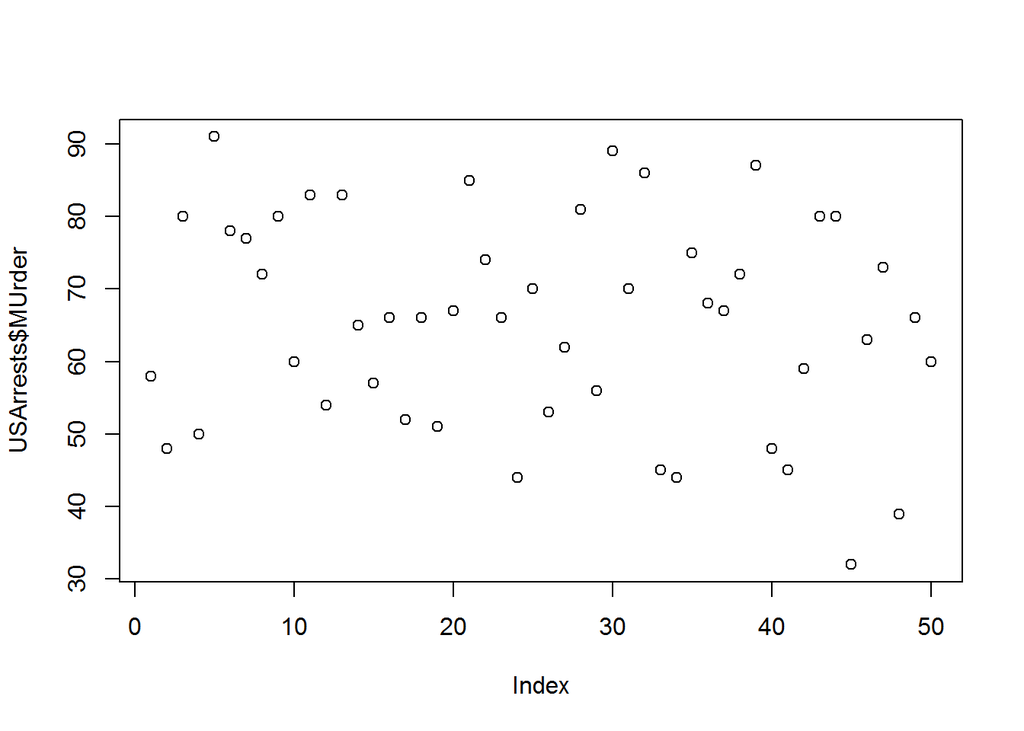

```r
plot(USArrests$UrbanPop, USArrests$MUrder)
```

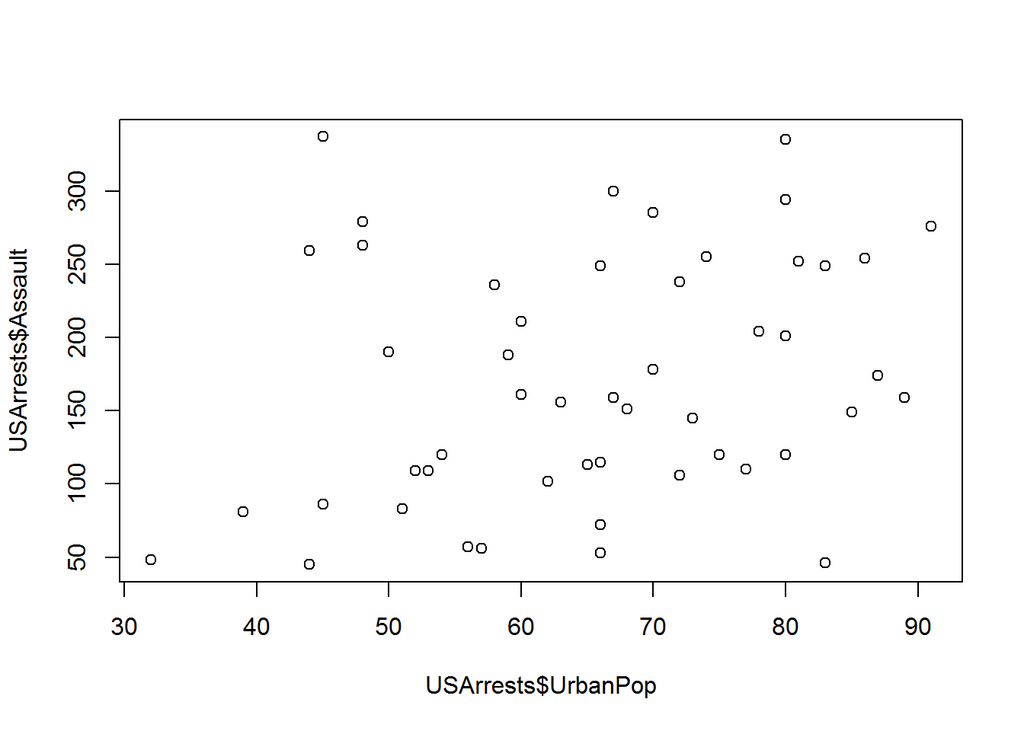

```r
plot(USArrests$UrbanPop, USArrests$Assault)
```

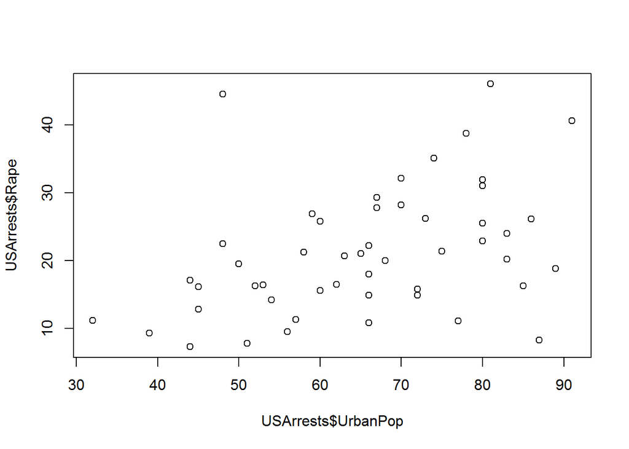

```r
plot(USArrests$UrbanPop, USArrests$Rape)
```

According to correlations and cattering plots, it can be said that;

1. There is no relation (r=0.06957262, because r<0.1) between UrbanPop and Murder.
2. There is a weak relation (r=0.25887170, because r<0.3) between UrbanPop and Assault. More observations are needed to find out relation between UrbanPop and Assault.
3. There is a moderate relation (r=0.41134124, because 0.3 < r < 0.5) between UrbanPop and Rape. According to scattering plot Rape against UrbanPop, there are some outliers, but there does seem to be a relationship between Rape and UrbanPop. There is an indication of a correlation and more analysis could be performed.

###### Q7

Which states has most and least assault, murder, and rape arrests?

###### A7

```r
# Most Assult State
Assult_max <- which(USArrests$Assault == max (USArrests$Assault))
print('Most Assult State:')
```

```
## [1] "Most Assult State:"
```

```r
rownames(USArrests)[Assult_max]
```

```
## [1] "North Carolina"
```

```r
# Least Assult State
Assult_min <- which(USArrests$Assault == min (USArrests$Assault))
print('Least Assult State:')
```

```
## [1] "Least Assult State:"
```

```r
rownames(USArrests)[Assult_min]
```

```
## [1] "North Dakota"
```

```r
# Most Murder State
Murder_max <- which(USArrests$Murder == max (USArrests$Murder))
print('Most Murder State:')
```

```
## [1] "Most Murder State:"
```

```r
rownames(USArrests)[Murder_max]
```

```
## [1] "Georgia"
```

```r
# Least Murder State
Murder_min <- which(USArrests$Murder == min (USArrests$Murder))
print('Least Murder State:')
```

```
## [1] "Least Murder State:"
```

```r
rownames(USArrests)[Murder_min]
```

```
## [1] "North Dakota"
```

```r
# Most Rape State
Rape_max <- which(USArrests$Rape == max (USArrests$Rape))
print('Most Rape State:')
```

```
## [1] "Most Rape State:"
```

```r
rownames(USArrests)[Rape_max]
```

```
## [1] "Nevada"
```

```r
# Least Rape State
Rape_min <- which(USArrests$Rape == min (USArrests$Rape))
print('Least Rape State:')
```

```
## [1] "Least Rape State:"
```

```r
rownames(USArrests)[Rape_min]
```

```
## [1] "North Dakota"
```

###### Q8

List the states which have assault arrests more than median of the country.

###### A8

```r
# Assult arrest of median of the cuntry
assault_median = median(USArrests$Assault)
assault_median
```

```
## [1] 159
```

```r
# List the states which have assault arrests more than median of the country
subset(USArrests, Assault > assault_median, select= c(UrbanPop, Assault))
```

```
##                UrbanPop Assault
## Alabama              58     236
## Alaska               48     263
## Arizona              80     294
## Arkansas             50     190
## California           91     276
## Colorado             78     204
## Delaware             72     238
## Florida              80     335
## Georgia              60     211
## Illinois             83     249
## Louisiana            66     249
## Maryland             67     300
## Michigan             74     255
## Mississippi          44     259
## Missouri             70     178
## Nevada               81     252
## New Mexico           70     285
## New York             86     254
## North Carolina       45     337
## Rhode Island         87     174
## South Carolina       48     279
## Tennessee            59     188
## Texas                80     201
## Wyoming              60     161
```

###### Q9

Which states are in the bottom 25% of murder?

###### A9

```r
# Bottom 25% of murder, lowQuartile
lower_quartille_murder_rate <- quantile(USArrests$Murder)[2]
lower_quartille_murder_rate
```

```
##   25%
## 4.075
```

```r
# States are in the bottom 25% of murder
subset(USArrests, Murder < lower_quartille_murder_rate, select= c(UrbanPop, Murder))
```

```
##               UrbanPop Murder
## Connecticut         77    3.3
## Idaho               54    2.6
## Iowa                57    2.2
## Maine               51    2.1
## Minnesota           66    2.7
## New Hampshire       56    2.1
## North Dakota        44    0.8
## Rhode Island        87    3.4
## South Dakota        45    3.8
## Utah                80    3.2
## Vermont             32    2.2
## Washington          73    4.0
## Wisconsin           66    2.6
```

###### Q10

Which states are in the top 25% of the murder.

###### A10

```r
# Top 25% of the murder
upper_quartile_murder_rate <- quantile(USArrests$Murder)[4]
upper_quartile_murder_rate
```

```
##   75%
## 11.25
```

```r
# States are in the top 25% of the murder
subset(USArrests, Murder > upper_quartile_murder_rate, select= c(UrbanPop, Murder))
```

```
##                UrbanPop Murder
## Alabama              58   13.2
## Florida              80   15.4
## Georgia              60   17.4
## Louisiana            66   15.4
## Maryland             67   11.3
## Michigan             74   12.1
## Mississippi          44   16.1
## Nevada               81   12.2
## New Mexico           70   11.4
## North Carolina       45   13.0
## South Carolina       48   14.4
## Tennessee            59   13.2
## Texas                80   12.7
```